# TP2 de projet sur R

# Importations et mise en forme

`library(readxl)` `library(questionr)` `library(labelled)` `library(dplyr)` `library(gtsummary)` `library(ggplot2)` `library(ggpubr)` `base_tp2 <- read_excel("../data/Base_TP2.xlsx")` `source("main_TP1.r",local = TRUE, chdir = TRUE)`

–> on evite ainsi d’executer les graphiques du TP1

# Questions preliminaires

```r
paste("Le nombre de ligne de notre base est :",nrow(base_tp2))
```

```
## [1] "Le nombre de ligne de notre base est : 53"
```

```r
paste("Le nombre de colonne de notre base est: ",ncol(base_tp2))
```

```
## [1] "Le nombre de colonne de notre base est:  30"
```

# Recodage et labellisation

—– > avant labelisation

```r
look_for(base_tp2)[,c("pos","label")]
```

```
## # A tibble: 30 × 2
##      pos label
##    <int> <chr>
##  1     1 <NA>
##  2     2 <NA>
##  3     3 <NA>
##  4     4 <NA>
##  5     5 <NA>
##  6     6 <NA>
##  7     7 <NA>
##  8     8 <NA>
##  9     9 <NA>
## 10    10 <NA>
## # ℹ 20 more rows
```

## —-> Labellisation

```r
var_label(base_tp2$region)<-"region du producteur"
var_label(base_tp2$departement)<-"departement du producteur"
var_label(base_tp2$sexe)<-"sexe du producteur"
var_label(base_tp2$age)<-"age du producteur"
var_label(base_tp2$sit_mat)<-"situation matrimonial du producteur"
var_label(base_tp2$si_chef_men)<-"statue du producteur dans le menage "
var_label(base_tp2$ethnie)<-"groupe ethnique du producteur"
var_label(base_tp2$occupation)<-"principal occupation du producteur"
var_label(base_tp2$formation)<-"niveau de formation du producteur"
var_label(base_tp2$niveau_alphabs)<-"niveau d'aphabetisation du producteur"
var_label(base_tp2$types_varietes)<-"type de variete utilise pour la production de sesame par le producteur"
var_label(base_tp2$types_varietes_1)<-"Utilisateurs de varietes traditionelles "
var_label(base_tp2$types_varietes_2)<-"Utilisateurs de varietes ameliorees "

#======> Les deux variables precedentes decoulent de la variable types_varietes leur existence decoule de la digitalisation du questionnaire !?

var_label(base_tp2$criteres_var)<-"liste des critere de choix des varietes de sesame retenu"
var_label(base_tp2$criteres_var_1)<-"critere rendement eleve"
var_label(base_tp2$criteres_var_2)<-"critere taille des grains"
var_label(base_tp2$criteres_var_3)<-"critere resistence aux maladides ravageurs"
var_label(base_tp2$criteres_var_4)<-"critere tolerence aux secheresses"
var_label(base_tp2$criteres_var_5)<-"critere tolerence aux inondations"
var_label(base_tp2$criteres_var_6)<-"critere faible charge de travail"
var_label(base_tp2$criteres_var_7)<-"critere faible quantite d'intrants"
var_label(base_tp2$criteres_var_8)<-"critere facile a transformer"
var_label(base_tp2$criteres_var_9)<-"critere haut teneur en huille"
var_label(base_tp2$criteres_var_10)<-"critere haut rendement apres transformations"
var_label(base_tp2$criteres_var_11)<-"critere demande sur le marche"
var_label(base_tp2$criteres_var_12)<-"critere bon gout"
var_label(base_tp2$criteres_var_13)<-"critere belle couleur"
var_label(base_tp2$criteres_var_14)<-"critere haut rendement en fourrage"
var_label(base_tp2$criteres_var_15)<-"critere qualite de fourrage"
var_label(base_tp2$criteres_var_16)<-"critere autre a preciser"
```

### Resultat de la labelisation

—–> apres labelisation

```r
look_for(base_tp2)[,c("pos","label")]
```

```
## # A tibble: 30 × 2
##      pos label
##    <int> <chr>
##  1     1 "region du producteur"
##  2     2 "departement du producteur"
##  3     3 "sexe du producteur"
##  4     4 "age du producteur"
##  5     5 "situation matrimonial du producteur"
##  6     6 "statue du producteur dans le menage "
##  7     7 "groupe ethnique du producteur"
##  8     8 "principal occupation du producteur"
##  9     9 "niveau de formation du producteur"
## 10    10 "niveau d'aphabetisation du producteur"
## # ℹ 20 more rows
```

## —-> Recodage

Les variables dont les informations sont incomplete(region,departement,…) ne seront pas recode

```r
# copie de la base initial

base_tp2_recode<-as.data.frame(base_tp2)

# ------------- variable sexe -------------

base_tp2_recode$sexe<-recode_factor(base_tp2_recode$sexe,
                        "1"="Homme",
                        "2"="Femme"

                        )

# ------------- variable sit_mat -------------

base_tp2_recode$sit_mat<-recode_factor(base_tp2_recode$sit_mat,
                        "1"="Marie (e)",
                        "2"="Veuf ve)",
                        "3"="Divorce (e)",
                        "4"="Separe (e)",
                        "5"="Celibataire"
                        )

# ------------- variable si_chef_men -------------

base_tp2_recode$si_chef_men <-recode_factor(base_tp2_recode$si_chef_men,
                                "1" = "femme du chef de ménage",
                                "2" = "chef de ménage",
                                "3" = "fils-fille du chef de ménage",
                                "99" = "Autres"
                                )
# ------------- variable ethnie -------------

base_tp2_recode$ethnie <-recode_factor(base_tp2_recode$ethnie,
                                 "1" = "Wolof",
                                "2" = "Pulaar/Toucouleur",
                                "3" = "Sérère",
                                "4" = "Mandika/Bambara",
                                "5" = "Soninké",
                                "6" = "Diola",
                                "7" = "Manjack",
                                "8"= "Bainouk",
                                "9" = "Maures",
                                "10" = "Balante",
                                "77" = "Autre"
                                )

# ------------- variable occupation -------------
```

### Remarque general sur la variable occupation

Dans le traitement de la variable `occupation`, les options sont limitées aux entiers jusqu’à 66, représentés par les chiffres de 1 à 6. La méthode consiste en l’utilisation d’une fonction nommée `generer_combinaisons()` qui retourne le libellé associé à un entier donné. Deux vecteurs sont utilisés : `all_combinaison_chiffre`, qui contient tous les entiers nécessaires, et `all_combinaison_label`, qui stocke leurs libellés respectifs. Pour ce faire, la fonction `generer_combinaisons()` est appliquée à chaque élément de `all_combinaison_chiffre`. En ce qui concerne le recodage proprement dit, une vérification est effectuée pour déterminer si chaque valeur de la colonne `occupation` dans `base_tp2_recode` correspond à l’une des anciennes valeurs nécessitant un recodage. Cette comparaison est réalisée avec les valeurs de la colonne “ancienne” du dataframe `correspondance_df` à l’aide de la fonction `dplyr::case_when()`. Si une correspondance est identifiée, la valeur de `occupation` dans `base_tp2_recode` est remplacée par la valeur correspondante de la colonne `nouvelle` du dataframe `correspondance_df`. Pour ce faire, la fonction `match()` est utilisée pour trouver l’indice de la valeur correspondante dans le vecteur `nouvelle`, basé sur l’indice de la valeur dans le vecteur `ancienne`. Les valeurs de `occupation` qui ne correspondent à aucune des anciennes valeurs nécessitant un recodage sont conservées inchangées. L’expression `TRUE \~ as.character(base_tp2_recode\$occupation)` dans `case_when()` est employée pour cela.

Dernier remarque, certains modalite de la variable `occupation` comme 22 sont sans interpretation possible.

je me permet de les remplacer par leur equivaleur a un chiffre .

```r
# certains producteurs ont plusieurs occupation ecrit sous forme genre 12


correspondances <- c(
  "1" = "Agriculture",
  "2" = "Activités extractives",
  "3" = "Activités de fabrication (Artisanat)",
  "4" = "Activité de transformation",
  "5" = "Production et distribution d'électricité et de gaz",
  "6" = "Production et distribution d'eau, assainissement, traitement des déchets et dépollution"
)
# Fonction pour générer les combinaisons d'occupations
generer_combinaisons <- function(chiffre) {
  # Séparation du nombre en chiffres individuels
  all_chiffre <- strsplit(as.character(chiffre), "")[[1]]
  all_chiffre<-c(all_chiffre,all_chiffre[1])

  # si je suis dans le cas 11 , 22 , 33, ect je garde que le premier chiffre
  if (length(all_chiffre==2)){          # pour pouvoir ecrire all_chiffre[2]
      if (all_chiffre[1]==all_chiffre[2]){
        all_chiffre <- all_chiffre[1] # supression du last
    }
  }
  # Récupération des libellés correspondant à chaque chiffre
  labels <- correspondances[all_chiffre]

  # Retourner les libellés concaténés avec des tirets <<_>>
  return(paste(labels, collapse = "-"))
}

chiffres <- 1:6

# Utilisation de la fonction expand.grid pour générer toutes les combinaisons possibles avec répétition
combinaisons <- expand.grid(chiffres, chiffres)

# Utilisation de paste0 pour combiner les chiffres en nombres a deux chiffres
all_combinaison_chiffre <- paste0(combinaisons$Var1, combinaisons$Var2)

# Ajout des entiers de l'intervalle [1,6]
all_combinaison_chiffre <- c(all_combinaison_chiffre, as.character(1:6))
all_combinaison_label<-sapply(all_combinaison_chiffre, generer_combinaisons) # applique la fonction a chaque element
        # trop de combinaison sans interet (...)

# Créer un data frame de correspondance
correspondance_df <- data.frame(ancienne = all_combinaison_chiffre, nouvelle = all_combinaison_label)

# Recodage de la variable "occupation"
base_tp2_recode$occupation <- case_when(
  base_tp2_recode$occupation %in% correspondance_df$ancienne ~
    correspondance_df$nouvelle[match(base_tp2_recode$occupation, correspondance_df$ancienne)],
  TRUE ~ as.character(base_tp2_recode$occupation)  # <-- conserve toutes les autres valeurs inchangées
)
# ici pas de recode_factor car on <<definit les levels a la volle et non simultanement>>



# ------------- variable formation -------------

base_tp2_recode$formation <-recode_factor(base_tp2_recode$formation,
                                "1" = "Non scolarisé",
                                "2" = "Élémentaires",
                                "3" = "Moyen",
                                "4" = "Secondaire",
                                "5" = "Licence",
                                "6" = "Master",
                                "7" = "Doctorat",
                                "99" = "Ne sait pas"
                                )

# ------------- variable niveau_alphabs -------------

base_tp2_recode$niveau_alphabs <-recode_factor(base_tp2_recode$niveau_alphabs,
                                     "0" = "Sans niveau",
                                     "1" = "Sais lire dans une langue",
                                     "2" = "Sais lire et écrire dans une"
                                     )

# ------------- variable types_varietes -------------

base_tp2_recode$types_varietes <-recode_factor(base_tp2_recode$types_varietes,
                                "1"= "Traditionelles",
                                "2"="Ameliorees",
                                "1 2" = "Traditionelles-Ameliorees",
                                "2 1" = "Traditionelles-Ameliorees"
                                )

# ------------- variable types_varietes_1 -------------

base_tp2_recode$types_varietes_1 <-recode_factor(base_tp2_recode$types_varietes_1,
                                "0"=" NON",
                                "1"="Oui"
                                )

# ------------- variable types_varietes_2 -------------

base_tp2_recode$types_varietes_2 <-recode_factor(base_tp2_recode$types_varietes_2,
                                "0"=" NON",
                                "1"="Oui"
                                )

# ------------- variable criteres_var -------------

# pas de recodage,c'est une liste des criteres retenu par le producteur

# ------------- variable criteres_var_nb , nb in [1,16] -------------

for (i in 1:16){
nom_var<-paste("criteres_var_",i,sep="")
base_tp2_recode[[nom_var]] <-recode_factor(base_tp2_recode[[nom_var]], # Technique du TP1
                                "0"="Non",
                                "1"="Oui"
)

}
```

## Resultat du recodage

```r
head(base_tp2_recode)
```

```
##   region departement  sexe age   sit_mat                  si_chef_men  ethnie
## 1      5          53 Femme  35 Marie (e)      femme du chef de ménage Balante
## 2      5          53 Homme  50 Marie (e)               chef de ménage   Wolof
## 3      2          22 Femme  35 Marie (e)      femme du chef de ménage   Wolof
## 4      1          12 Homme  25 Marie (e) fils-fille du chef de ménage  Sérère
## 5      5          52 Femme  60 Marie (e)      femme du chef de ménage   Autre
## 6      3          31 Homme  36 Marie (e)      femme du chef de ménage  Sérère
##              occupation     formation niveau_alphabs            types_varietes
## 1 Activités extractives    Secondaire           <NA>                Ameliorees
## 2           Agriculture Non scolarisé    Sans niveau            Traditionelles
## 3           Agriculture         Moyen           <NA>            Traditionelles
## 4 Activités extractives       Licence           <NA>            Traditionelles
## 5           Agriculture         Moyen           <NA>            Traditionelles
## 6           Agriculture   Ne sait pas           <NA> Traditionelles-Ameliorees
##   types_varietes_1 types_varietes_2             criteres_var criteres_var_1
```

[output cut: 34 more lines]

```r
# la variable niveau_alphabs contient de base des valeurs NA
```

```r
base_tp2_recode %>%
  select( criteres_var_1: criteres_var_16)%>%
  head()
```

```
##   criteres_var_1 criteres_var_2 criteres_var_3 criteres_var_4 criteres_var_5
## 1            Oui            Non            Non            Non            Non
## 2            Oui            Non            Non            Oui            Non
## 3            Oui            Non            Non            Non            Oui
## 4            Oui            Non            Non            Oui            Non
## 5            Oui            Oui            Oui            Oui            Non
## 6            Oui            Oui            Non            Non            Non
##   criteres_var_6 criteres_var_7 criteres_var_8 criteres_var_9 criteres_var_10
## 1            Non            Non            Non            Non             Non
## 2            Oui            Oui            Non            Non             Non
## 3            Oui            Non            Non            Non             Non
## 4            Oui            Oui            Non            Non             Non
## 5            Oui            Oui            Oui            Oui             Non
## 6            Non            Non            Non            Non             Non
##   criteres_var_11 criteres_var_12 criteres_var_13 criteres_var_14
## 1             Non             Oui             Oui             Non
## 2             Oui             Non             Oui             Non
## 3             Non             Non             Non             Non
## 4             Non             Non             Non             Oui
## 5             Oui             Non             Oui             Oui
## 6             Non             Non             Oui             Oui
##   criteres_var_15 criteres_var_16
## 1             Non             Non
## 2             Non             Non
## 3             Non             Non
## 4             Oui             Non
## 5             Non             Non
## 6             Non             Non
```

# Analyses descriptives

## Repartition suivant l’age

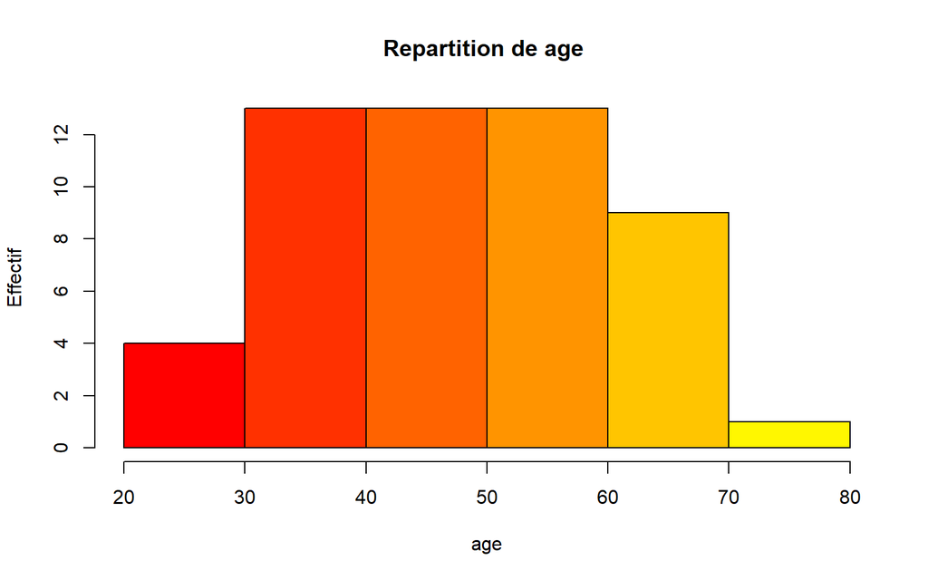

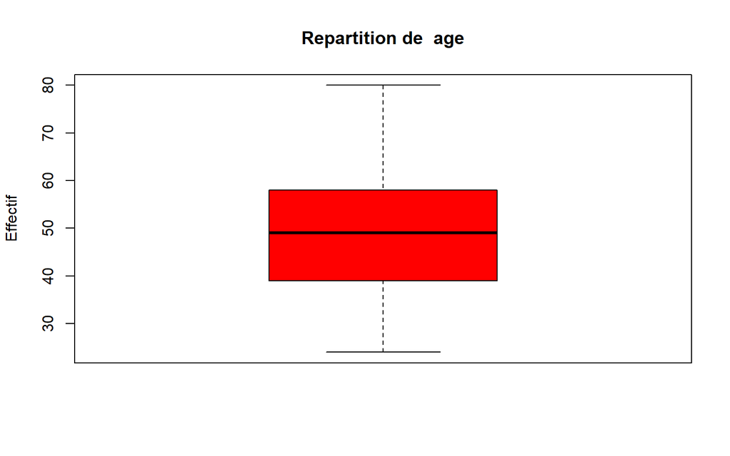

```
## [1] "--------------------------------------------------------------------------------------------------------------"
```

```
## $moyenne
## [1] 48.60377
##
## $mediane
## [1] 49
##
## $mode
## [1] 45
##
## $Ecart_type
## [1] 12.91293
##
## $variance
## [1] 166.7438
##
## $etendue
## [1] 24 80
##
## $quantiles
## 25% 50% 75%
##  39  49  58
```

```r
univarie(projet_=base_tp2_recode,"age",tableau=TRUE,histogramme=TRUE,boite_moustache=TRUE)
```

Interpretation

Les producteurs ont une moyenne d’age de 48 ans et un age median de 49 ans

```r
tableau_effectifs
```

```
##   intervalle Freq
## 1  [24,36.4]   11
## 2  (36.4,45]   14
## 3  (45,52.2]    7
## 4  (52.2,60]   11
## 5    (60,80]   10
```

## Repartition suivant le sexe

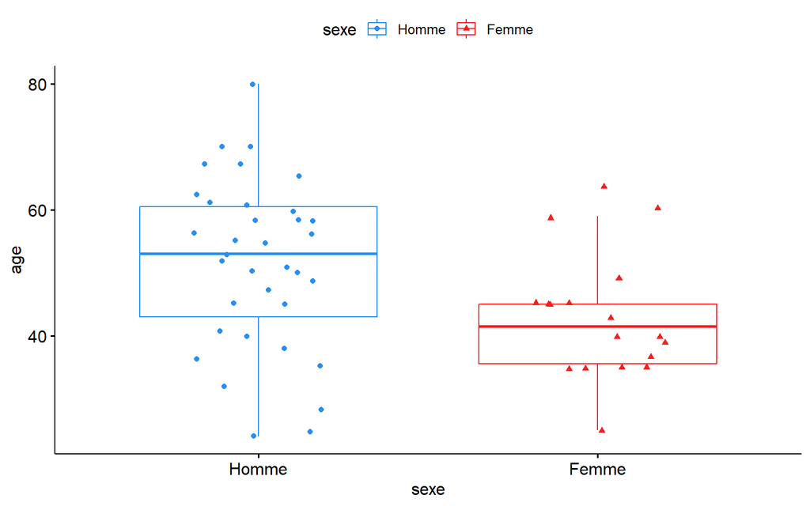

```r
ggboxplot(base_tp2_recode,
x = "sexe", y = "age",
color = "sexe", palette = c("#288EF2", "#F22222"),
add = "jitter", shape = "sexe"
)
```

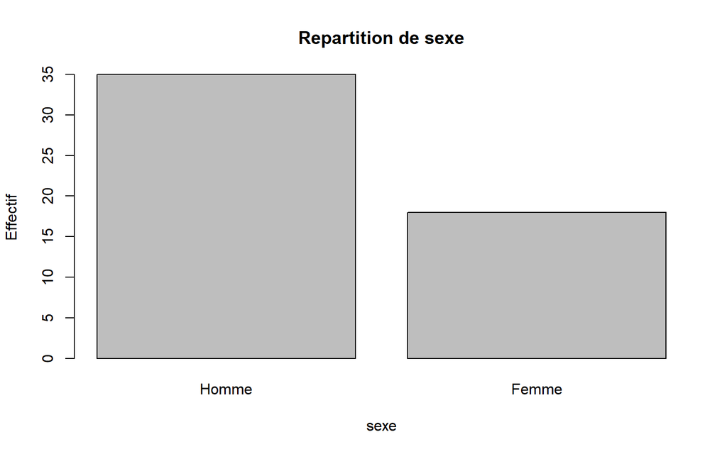

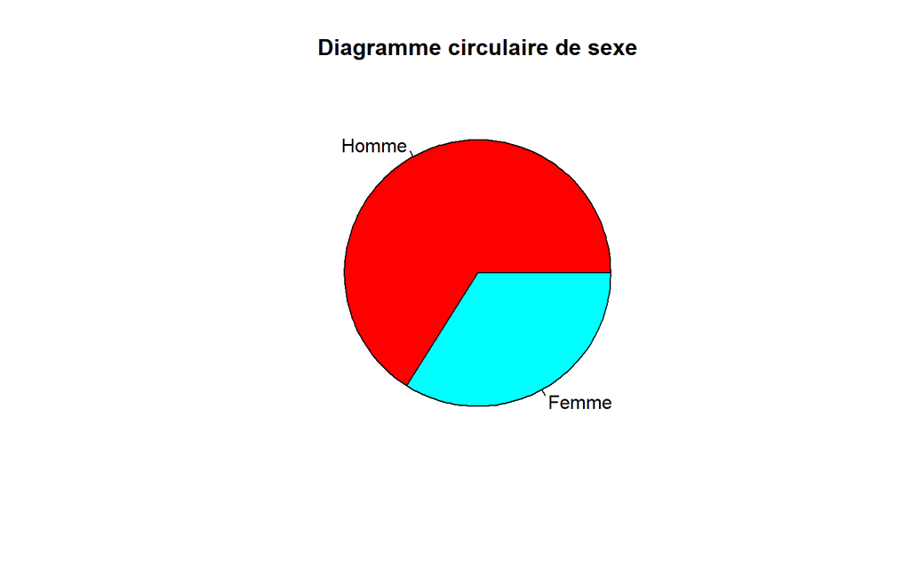

```r
univarie(projet_=base_tp2_recode,"sexe",tableau=TRUE,diagramme_circulaire=TRUE,diagramme_baton=TRUE)
```

Interpretation

Il y’a presque deux fois plus de producteur Homme que de producteur Femme.

```r
tableau_effectifs
```

```
##   Categorie Effectif Pourcentage
## 1     Homme       35    66.03774
## 2     Femme       18    33.96226
```

## Repartition suivant le statut dans le menage

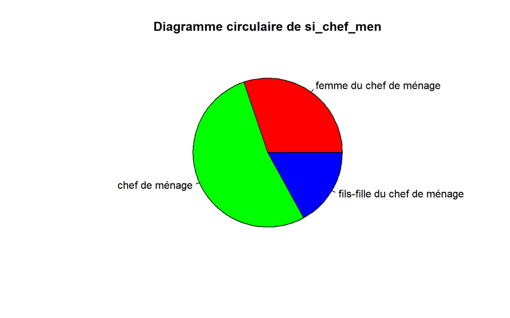

```r
univarie(projet_=base_tp2_recode,"si_chef_men",diagramme_circulaire=TRUE)
```

```r
tableau_effectifs
```

```
##   Categorie Effectif Pourcentage
## 1     Homme       35    66.03774
## 2     Femme       18    33.96226
```

Interpretation

pres de la moitie des producteurs ne sont pas des chef de menages, ce sont soit des femmes de chef de menage soit fils ou fille du chef de menage, on est alors tente de verifier la proportion de femme producteur chef de menage

```r
tableau_effectifs
```

[output not shown]

```r
bivarie("sexe","si_chef_men",tableau=TRUE,projet_=base_tp2_recode,nuage_point=TRUE)
resultats
```

```
##   tableau_croise.Var1          tableau_croise.Var2 tableau_croise.Freq
## 1               Homme      femme du chef de ménage                   1
## 2               Femme      femme du chef de ménage                  15
## 3               Homme               chef de ménage                  27
## 4               Femme               chef de ménage                   1
## 5               Homme fils-fille du chef de ménage                   7
## 6               Femme fils-fille du chef de ménage                   2
```

Interpretation

Une seul femme producteur est chef de menage

## Repartition suivant l’occupation

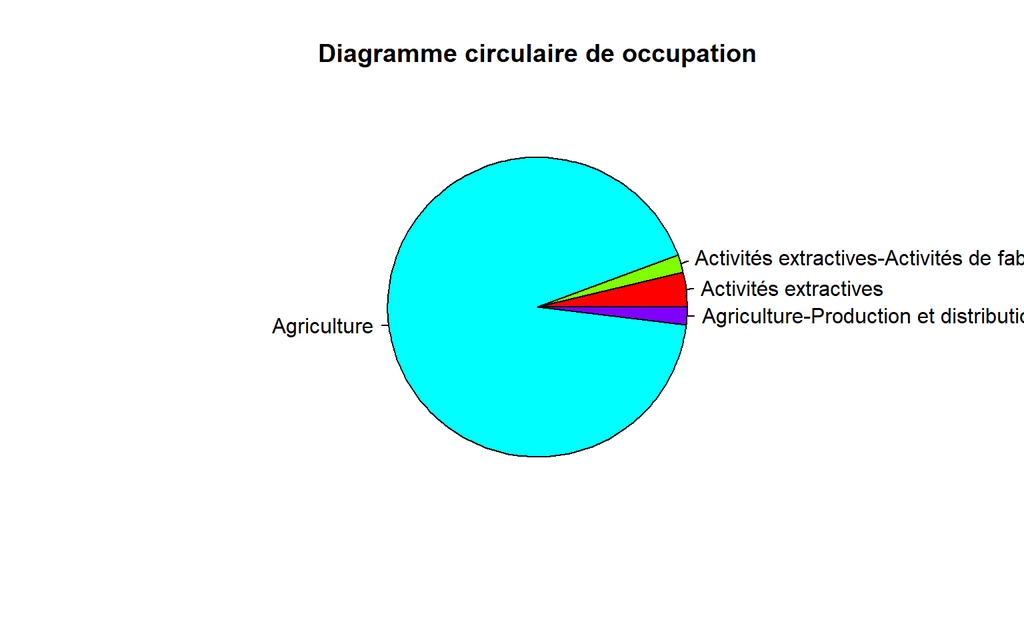

```r
# dans ma fonction univarie() j'avais pas prevu que mes colonnes auront des labels (v2 ...)
univarie(projet_=base_tp2_recode,"occupation",diagramme_circulaire=TRUE,tableau=TRUE)
```

```r
tableau_effectifs
```

```
##                                                                          Categorie
## 1                                                            Activités extractives
## 2 Activités extractives-Activités de fabrication (Artisanat)-Activités extractives
## 3                                                                      Agriculture
## 4       Agriculture-Production et distribution d'électricité et de gaz-Agriculture
##   Effectif Pourcentage
## 1        2    3.773585
## 2        1    1.886792
## 3       49   92.452830
## 4        1    1.886792
```

Interpretation

Les agriculteurs sont largement dominant avec pres de 92% des effectifs.

## Repartition suivant le type de variete utilise

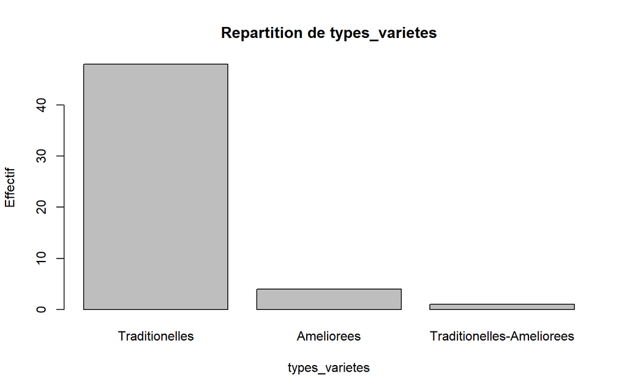

```r
univarie(projet_=base_tp2_recode,"types_varietes",diagramme_baton  =TRUE,tableau=TRUE)
```

Interpretation

Les varietes traditionelles sont largement plebicite tandisque un melange entre variete traditionelles et variete amelirer n’est que tres peu solicite

```r
# En construction
```